# archivo profe Carlos Ariel

Profe, esta fue la solución para leer los archivos. No sé si la intención sea leer usando la función `read.delim()` por que la forma de los datos no permite por default leer la base de datos. Es necesario complementarla con algo más. En mi caso use la libreria `tidyr` que hace parte de `tidyverse`.

La solución que implemente, fue la siguiente:

```r
read.delim("jan17Weather.csv") %>% tidyr::separate("date.PRCP.SNOW.TMAX.TMIN", c("date", "PRCP", "SNOW", "TMAX", "TMIN"), sep = "\t") %>% mutate(date = as.Date(date)) %>% mutate_if(is.character, as.numeric) %>% head()
```

|  | date | PRCP | SNOW | TMAX | TMIN |
| --- | --- | --- | --- | --- | --- |
| 1 | 2017-01-01 | 0.3149606 | 0.7874016 | 35.06 | 21.02 |
| 2 | 2017-01-02 | 0.1181102 | 0.1181102 | 28.94 | 21.02 |
| 3 | 2017-01-03 | 0.0000000 | 0.0000000 | 23.00 | 6.98 |
| 4 | 2017-01-04 | 0.0000000 | 0.0000000 | 21.92 | 3.92 |
| 5 | 2017-01-05 | 0.0000000 | 0.0000000 | 28.94 | 8.96 |
| 6 | 2017-01-06 | 0.0000000 | 0.0000000 | 35.06 | 12.92 |

Esto de acuerdo a, que al leer el archivo nos va a retornar un dataframe con solo una columna. De esta forma:

```r
# Not run
read.delim("jan17Weather.csv")
```

|  | date.PRCP.SNOW.TMAX.TMIN |
| --- | --- |
| 1 | 2017-01-01T00:00:00Z\t0.31496062992125984\t0.7874015748031497\t35.06\t21.02 |
| 2 | 2017-01-02T00:00:00Z\t0.11811023622047245\t0.11811023622047245\t28.94\t21.02 |
| 3 | 2017-01-03T00:00:00Z\t0\t0\t23\t6.979999999999997 |
| 4 | 2017-01-04T00:00:00Z\t0\t0\t21.919999999999998\t3.919999999999998 |
| 5 | 2017-01-05T00:00:00Z\t0\t0\t28.94\t8.96 |
| 6 | 2017-01-06T00:00:00Z\t0\t0\t35.06\t12.919999999999998 |

Al sacar los nombres del data frame, evidenciamos que únicamente tenemos una columna.

```r
read.delim("jan17Weather.csv") %>% names()
```

```
[1] "date.PRCP.SNOW.TMAX.TMIN"
```

Donde, la primera y última columna tienen un `"`. Esto puede ser contra intuitivo y sucede porque los datos del archivo *.csv* tienen la siguiente estructura

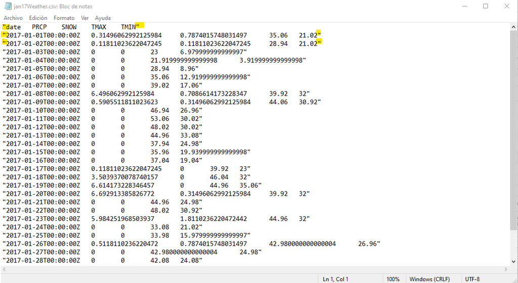

Anotación uno

con unas `"` al inicio y al final entendiendo la estructura de datos como si fuese una sola columna de tipo string.

O si aplicamos el atributo `quote` de la función `read.delim()` nos retornara la siguiente tabla, la cual supongo es la que usted tiene:

```r
# Not run
read.delim("jan17Weather.csv", quote = "")
```

|  | X.date | PRCP | SNOW | TMAX | TMIN. |
| --- | --- | --- | --- | --- | --- |
| 1 | "2017-01-01T00:00:00Z | 0.3149606 | 0.7874016 | 35.06 | 21.02" |
| 2 | "2017-01-02T00:00:00Z | 0.1181102 | 0.1181102 | 28.94 | 21.02" |
| 3 | "2017-01-03T00:00:00Z | 0.0000000 | 0.0000000 | 23.00 | 6.979999999999997" |
| 4 | "2017-01-04T00:00:00Z | 0.0000000 | 0.0000000 | 21.92 | 3.919999999999998" |
| 5 | "2017-01-05T00:00:00Z | 0.0000000 | 0.0000000 | 28.94 | 8.96" |
| 6 | "2017-01-06T00:00:00Z | 0.0000000 | 0.0000000 | 35.06 | 12.919999999999998" |

Resultando esta forma de lectura contra intuitiva, porque puede tender a pensarse que por tener `"` el atributo `quote` de la función `read.delim()` leería los valores sin problemas, pero este atributo únicamente funciona cuando *cada una* de las columnas esta rodeada de `"` al inicio y al final.

Para solucionar esto, existen algunas alternativas. Podemos, reemplazar directamente el archivo *.csv* quitandole las `"` y después volviendo a leer el archivo, esto lo solucionaría.

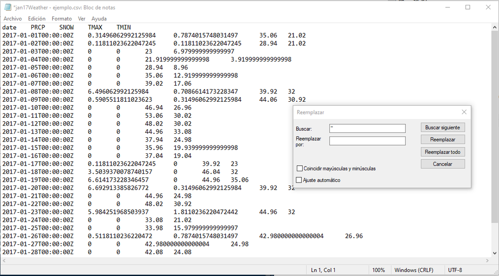

Anotación dos

```r
# Not tun
read.delim("jan17Weather - ejemplo.csv")
```

|  | date | PRCP | SNOW | TMAX | TMIN |
| --- | --- | --- | --- | --- | --- |
| 1 | 2017-01-01T00:00:00Z | 0.3149606 | 0.7874016 | 35.06 | 21.02 |
| 2 | 2017-01-02T00:00:00Z | 0.1181102 | 0.1181102 | 28.94 | 21.02 |
| 3 | 2017-01-03T00:00:00Z | 0.0000000 | 0.0000000 | 23.00 | 6.98 |
| 4 | 2017-01-04T00:00:00Z | 0.0000000 | 0.0000000 | 21.92 | 3.92 |
| 5 | 2017-01-05T00:00:00Z | 0.0000000 | 0.0000000 | 28.94 | 8.96 |
| 6 | 2017-01-06T00:00:00Z | 0.0000000 | 0.0000000 | 35.06 | 12.92 |

*La base de datos “jan17Weather - ejemplo.csv” contiene la modificación quitando las `"` del archivo original como muestra la Anotación dos.*

sin embargo, hacer esto puede ser complejo si estamos conectados a una base de datos o si el archivo o base de datos contiene un alto nivel de datos o si no se quiere modificar la base de datos inicial. Puede usarse la combinación de los siguientes comandos, los cuales use para leer el archivo *.csv*, Donde:

```r
# Not run
read.delim("jan17Weather.csv") %>% tidyr::separate("date.PRCP.SNOW.TMAX.TMIN", c("date", "PRCP", "SNOW", "TMAX", "TMIN"), sep = "\t")
```

|  | date | PRCP | SNOW | TMAX | TMIN |
| --- | --- | --- | --- | --- | --- |
| 1 | 2017-01-01T00:00:00Z | 0.31496062992125984 | 0.7874015748031497 | 35.06 | 21.02 |
| 2 | 2017-01-02T00:00:00Z | 0.11811023622047245 | 0.11811023622047245 | 28.94 | 21.02 |
| 3 | 2017-01-03T00:00:00Z | 0 | 0 | 23 | 6.979999999999997 |
| 4 | 2017-01-04T00:00:00Z | 0 | 0 | 21.919999999999998 | 3.919999999999998 |
| 5 | 2017-01-05T00:00:00Z | 0 | 0 | 28.94 | 8.96 |
| 6 | 2017-01-06T00:00:00Z | 0 | 0 | 35.06 | 12.919999999999998 |

Después de separa los valores en columna, vemos que `R` aún tiene los valores de columnas como caracteres, por lo tanto, implementamos un `mutate()` para modificar el tipo de los vectores dentro del data frame. De la siguiente manera:

[output not shown]

Donde, dentro del mismo pipeline indicamos: `mutate(date = as.Date(date))` para modificar la columna `date` a tipo `<date>` y luego con el comando: `mutate_if(is.character, as.numeric)` indicamos que nos modifique todas las columnas que sean tipo caracter, en este caso las columnas faltantes `PRCP`, `SNOW`, `TMAX`, `TMIN` y que las transforme a tipo `<dbl>`. Es decir:

0. Todas las columans son caracteres.
1. El comando: `mutate(date = as.Date(date))` modifica las columna `date` a tipo fecha.
2. El comando: `mutate_if()` necesita una condición, en nuestro caso es `is.character()` metodo que devuelve valores booleanos. Y necesita un metodo para modificar los valores que cumplan la condición, en nuestro caso `as.numeric()` método que transforma valores a numeros (incluidos tipo `double` o `<dbl>`).

*Es necesario denotar que los argumentos ingresados a `mutate_if` son métodos sin párentesis.*

¡Saludos profe!

att: [Sergio Mora Pardo](https://github.com/sergiomora03)